# Adult

TM

februĂˇr 28.

# Executive summary

This **Documentation** was created to introduce a process of classifying 32561 adults by their earnings based on their social and professional parameters.There are two earning groups set up: >50k and <=50k.

There are **two basic dataset** for the analysis. One for training the models and one for testing. Both datasets have the same structure. The aim of analysis is finding a model that can predict the earning category of an individual based on the characteristics (features) provided. Characteristics (features):

**Feature: type**

- age: continuous
- workclass: category
- fnlwgt: continuous
- education: category
- education-num: continuous
- marital-status: category
- occupation: category
- relationship: category
- race: category
- sex: category
- capital-gain: continuous
- capital-loss: continuous
- hours-per-week: continuous
- native-country

**Process model building**, first the test and training sets are compared if they follow the same pattern. Second step, features are checked if they are suitable for the analysis. Third, based on the findings features are modified. As a fourts step, models are built and evaluated. Fifth, step models are tested on theseparated test set to verify if they provide good results on a separated dataset as well.

**Dataset credits**: Lichman, M. (2013). UCI Machine Learning Repository: http://archive.ics.uci.edu/ml. Irvine, CA: University of California, School of Information and Computer Science.

# Testing variables & features

When loading datasets all non-numeric variables are treated as characters as in case of basic statistics factors sometimes mix up the calculations.

### Target variable: earning

Target variable is a binary variable with two possible values: - >50k , meaning yearly earnings above USD 50,000 and - <=50k , meaning yearly earnings below (or equal to) USD 50,000.

*Characteristics of earnings*

| Length | Class | Mode |
| --- | --- | --- |
| 32561 | character | character |

*Number of observations in each group*

| <=50K | >50K |
| --- | --- |
| 24720 | 7841 |

### Training set vs Test set

Test and training set is to be compared if they show the same distribution. As they are provided as separate datasets, it should be tested if they have the same characteristics, really randomly separated ones.

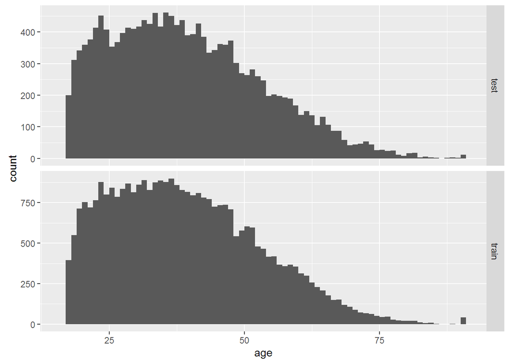

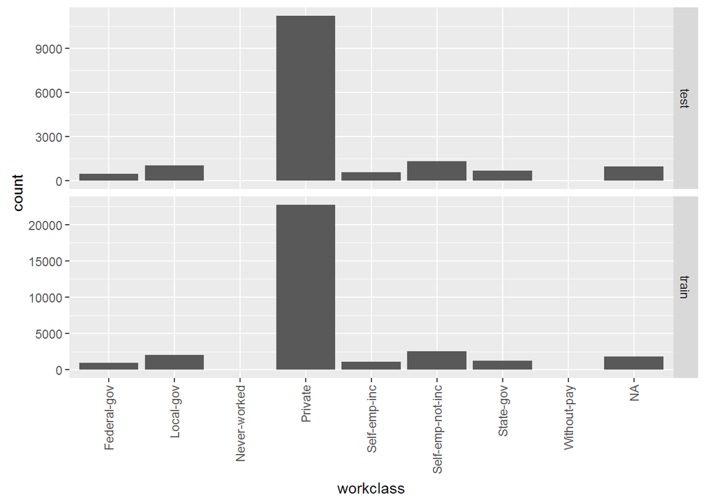

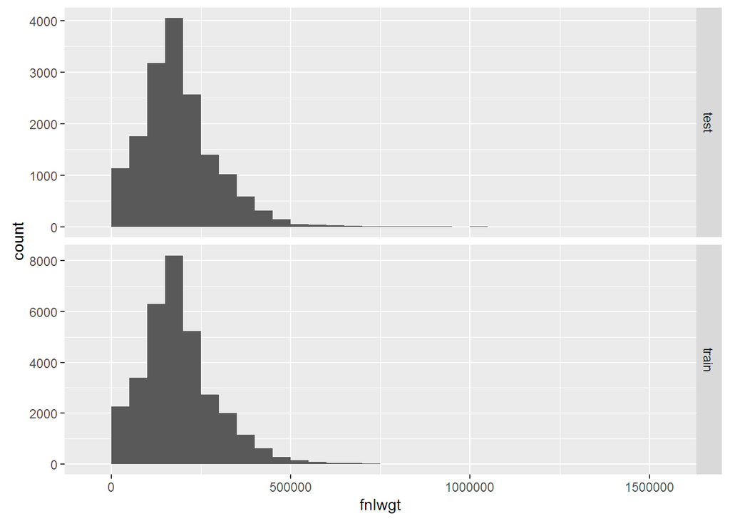

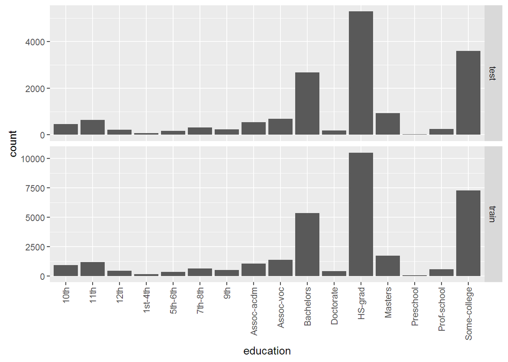

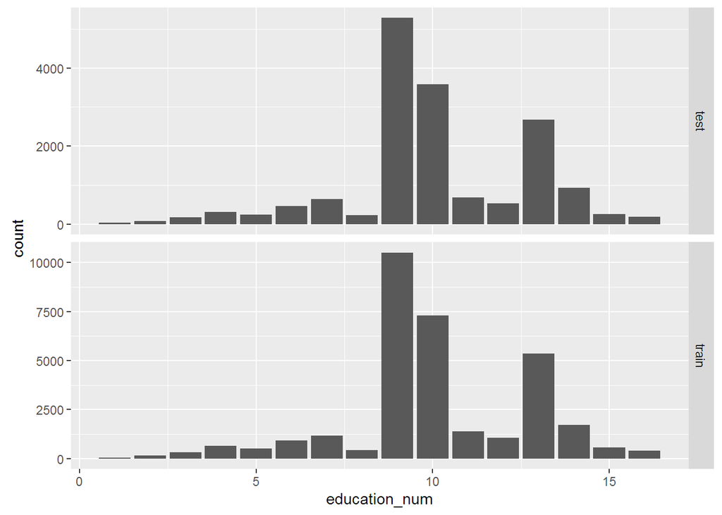

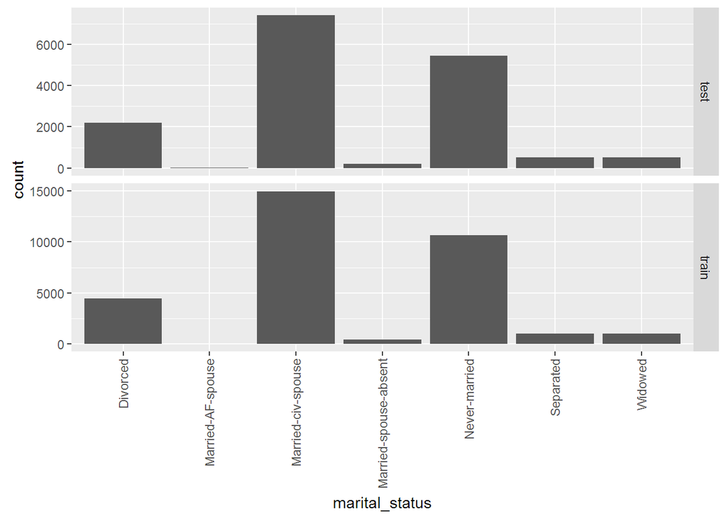

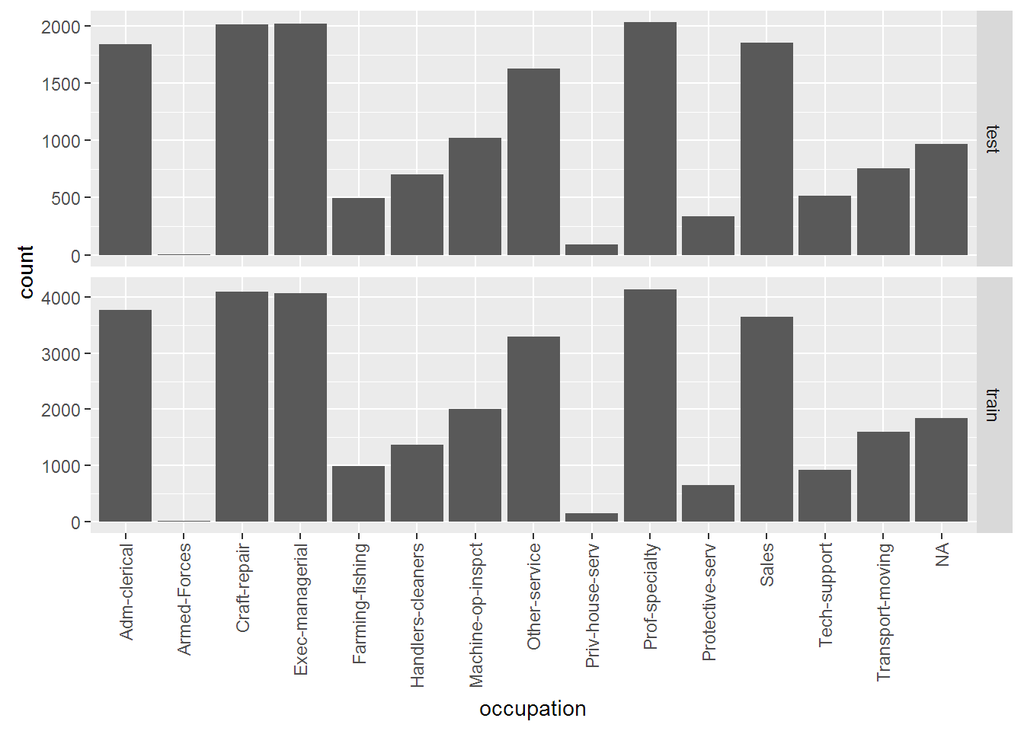

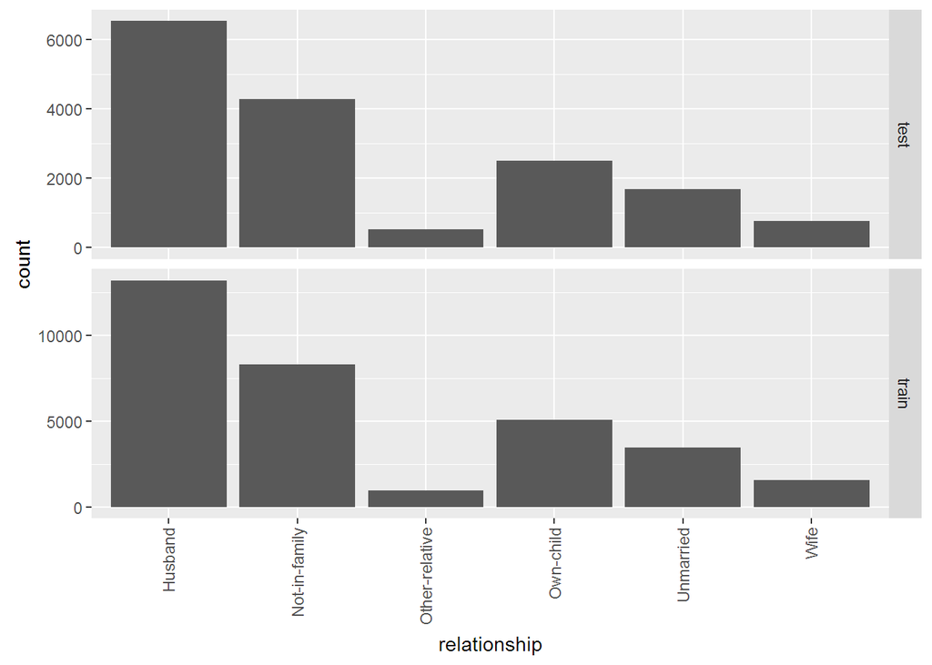

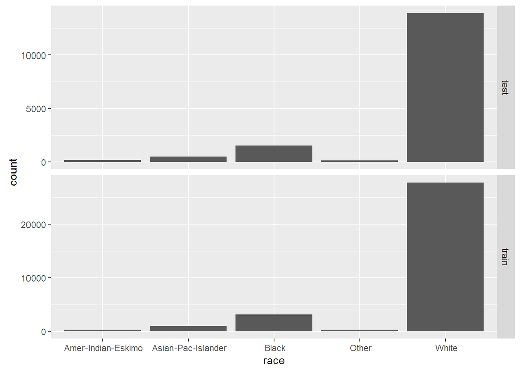

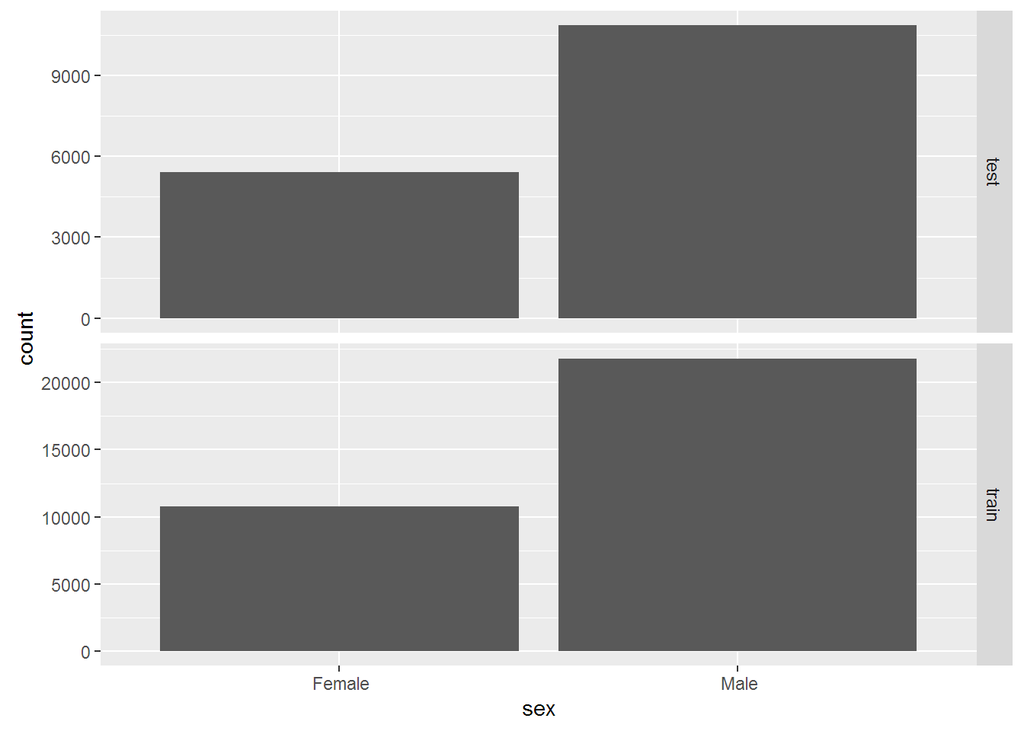

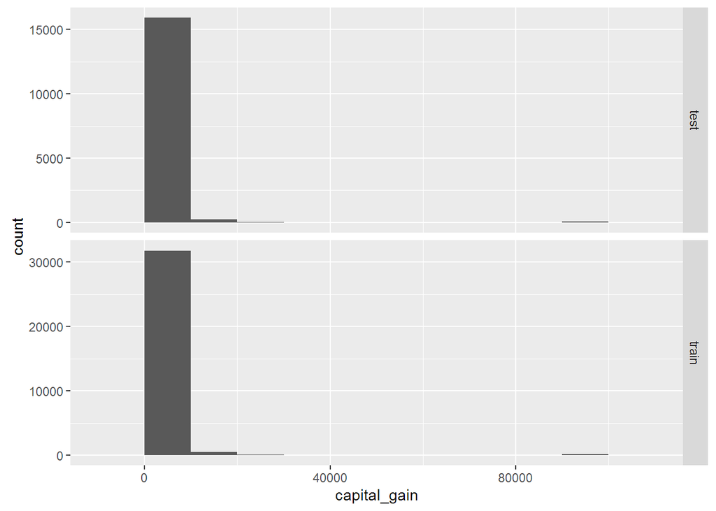

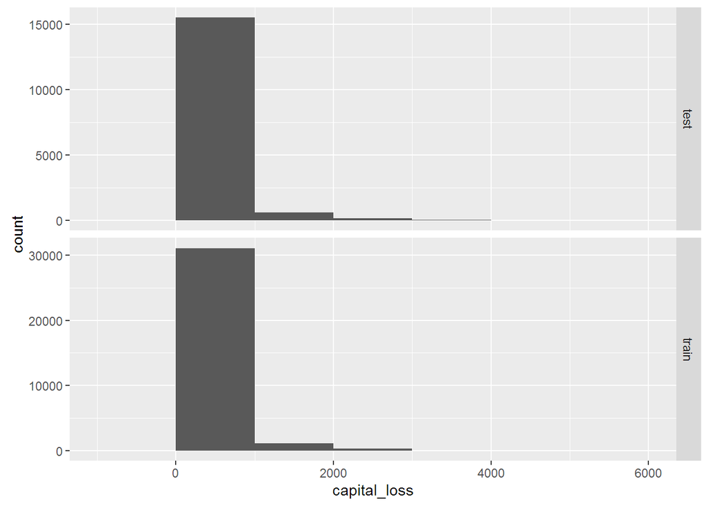

[2 more figures not shown]

Test and training sets show the same distribution, so I decided to use them in this division.

### Checking features - training set

All the features should be checked if they are suitable for using in model building. I prepare distribution plots, check for missing values and outliers.

#### Feature: age

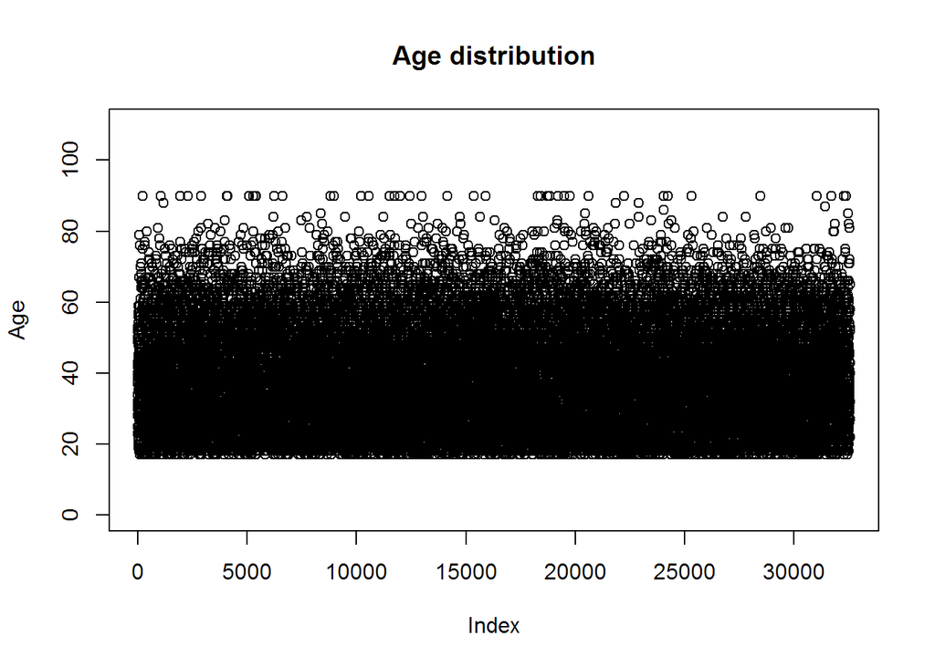

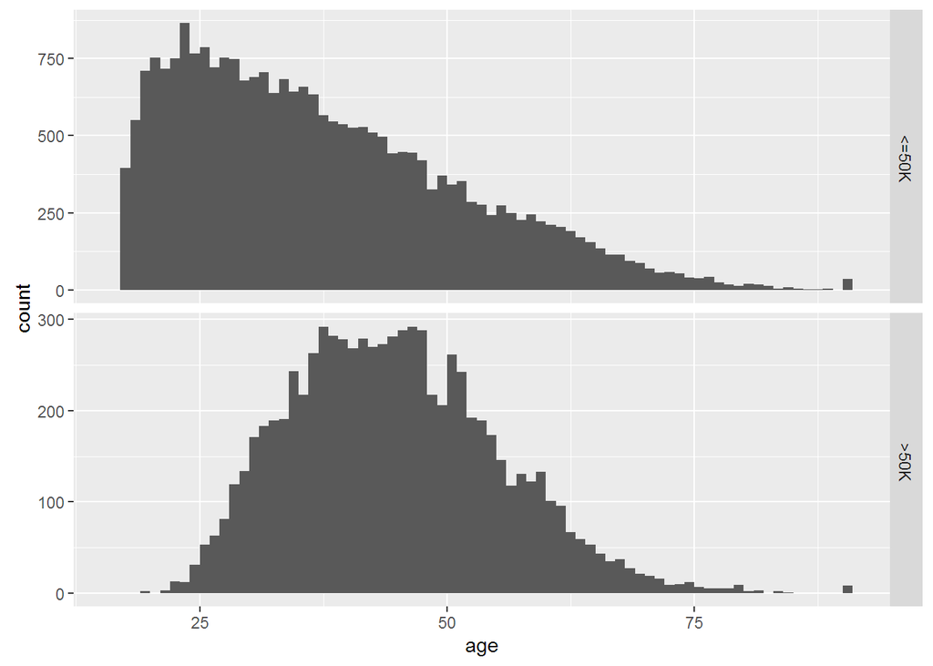

*General statistics of age*

| Min. | 1st Qu. | Median | Mean | 3rd Qu. | Max. |
| --- | --- | --- | --- | --- | --- |
| 17 | 28 | 37 | 38.58 | 48 | 90 |

The number of mising values is 0. As it could be seen the number of 90-year-old participants is quite high compared to the neighbouring values. The reason for this could be from more sources, e.g. it really covers all ages >=90.

*Distribution of age, in numbers*

*17 : 395*, *18 : 550*, *19 : 712*, *20 : 753*, *21 : 720*, *22 : 765*, *23 : 877*, *24 : 798*, *25 : 841*, *26 : 785*, *27 : 835*, *28 : 867*, *29 : 813*, *30 : 861*, *31 : 888*, *32 : 828*, *33 : 875*, *34 : 886*, *35 : 876*, *36 : 898*, *37 : 858*, *38 : 827*, *39 : 816*, *40 : 794*, *41 : 808*, *42 : 780*, *43 : 770*, *44 : 724*, *45 : 734*, *46 : 737*, *47 : 708*, *48 : 543*, *49 : 577*, *50 : 602*, *51 : 595*, *52 : 478*, *53 : 464*, *54 : 415*, *55 : 419*, *56 : 366*, *57 : 358*, *58 : 366*, *59 : 355*, *60 : 312*, *61 : 300*, *62 : 258*, *63 : 230*, *64 : 208*, *65 : 178*, *66 : 150*, *67 : 151*, *68 : 120*, *69 : 108*, *70 : 89*, *71 : 72*, *72 : 67*, *73 : 64*, *74 : 51*, *75 : 45*, *76 : 46*, *77 : 29*, *78 : 23*, *79 : 22*, *80 : 22*, *81 : 20*, *82 : 12*, *83 : 6*, *84 : 10*, *85 : 3*, *86 : 1*, *87 : 1*, *88 : 3*, *89 : 0* and *90 : 43*

The number of these observations (in total) is not high, so I decided to drop age 90 as outlying numbers.

#### Feature: workclass

The number of missing values is quite high, 1836, in percents 5.6386475%. This is quite high, it should be decided to tranform or drop these observations.

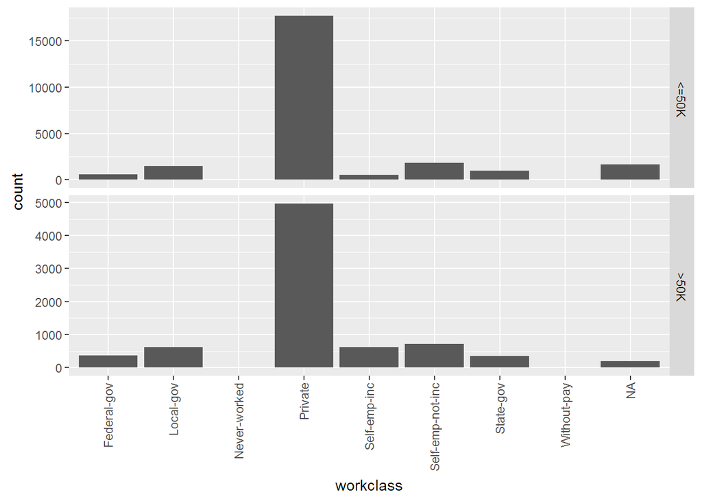

#### Feature: fnlwgt

This feature is a generated weight number based on social, economical and professional charactristics of the persons. Number of missing values is 0. General statistics show that the distribution is skewed:

```
##    Min. 1st Qu.  Median    Mean 3rd Qu.    Max.
##   12280  117800  178400  189800  237100 1485000
```

that could be followed on the histogram as well:

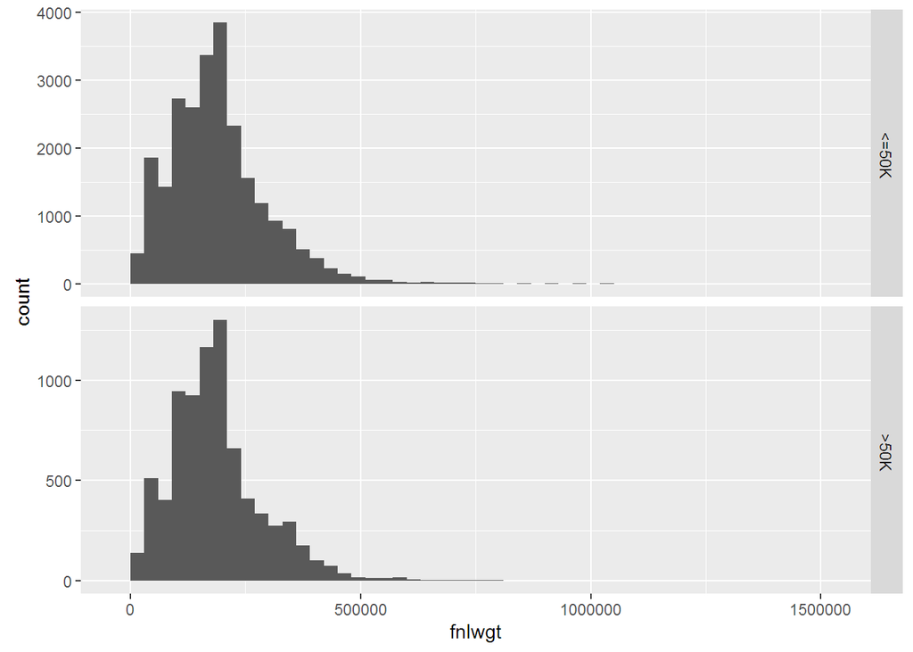

Number of values of *fnlwgt* above 750,000 is 38. Although that is a low number I decided to keep every observation, as a result of eyeballing the chart below:

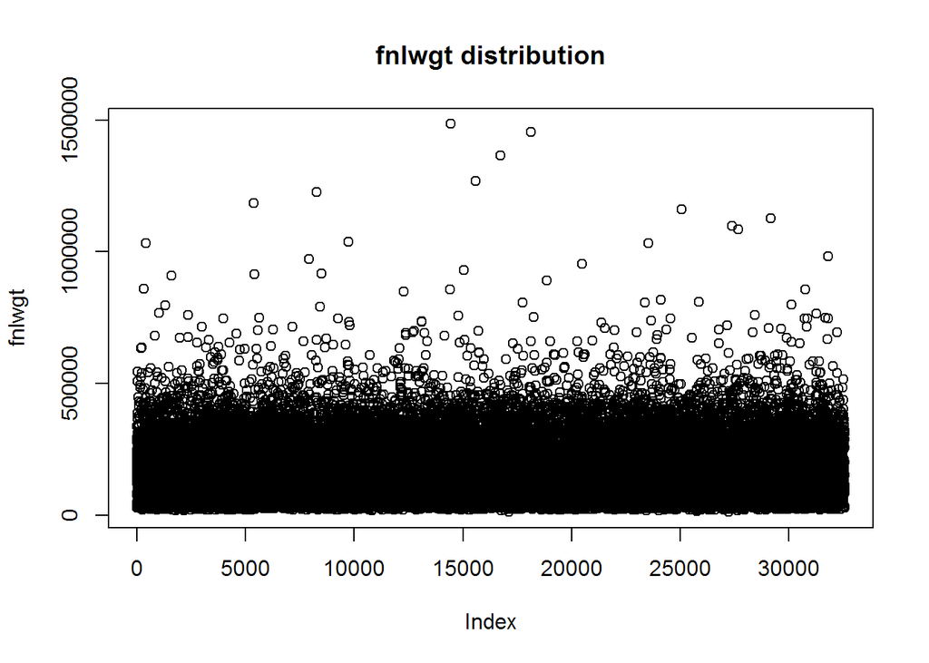

#### Feature: education

The number of missing values is 0, with a minimal skew in distribution.

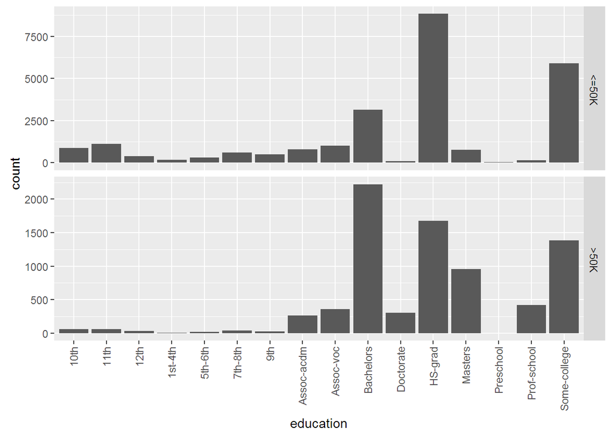

#### Feature: education_num

The number of missing values is 0. General statistics:

| Min. | 1st Qu. | Median | Mean | 3rd Qu. | Max. |
| --- | --- | --- | --- | --- | --- |
| 1 | 9 | 10 | 10.08 | 12 | 16 |

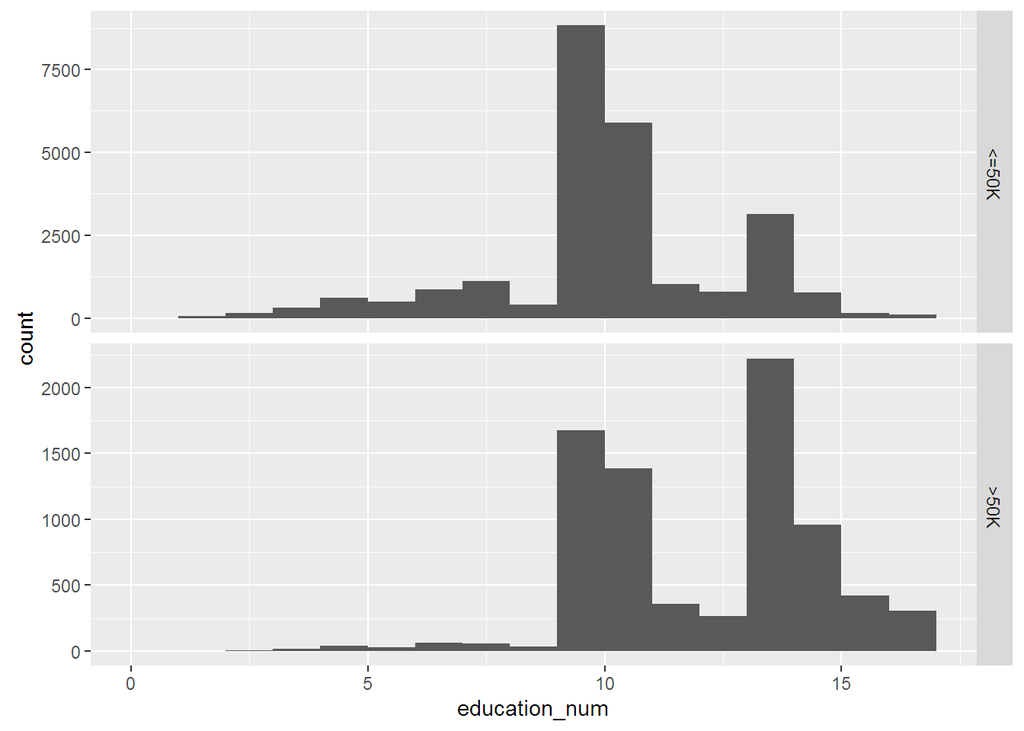

#### Feature: marital status

The number of missing values is 0.

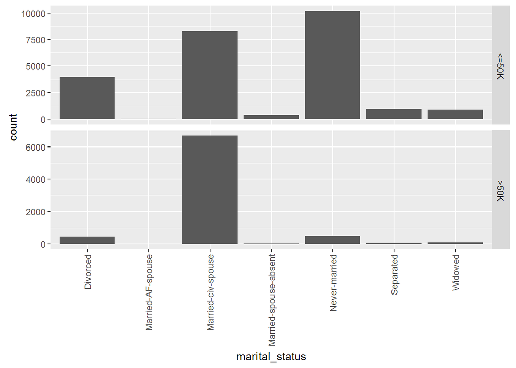

#### Feature: occupation

The number of missing values is quite high, 1843, in percents 5.6601456%. This is quite high, it should be decided to tranform or drop these observations.

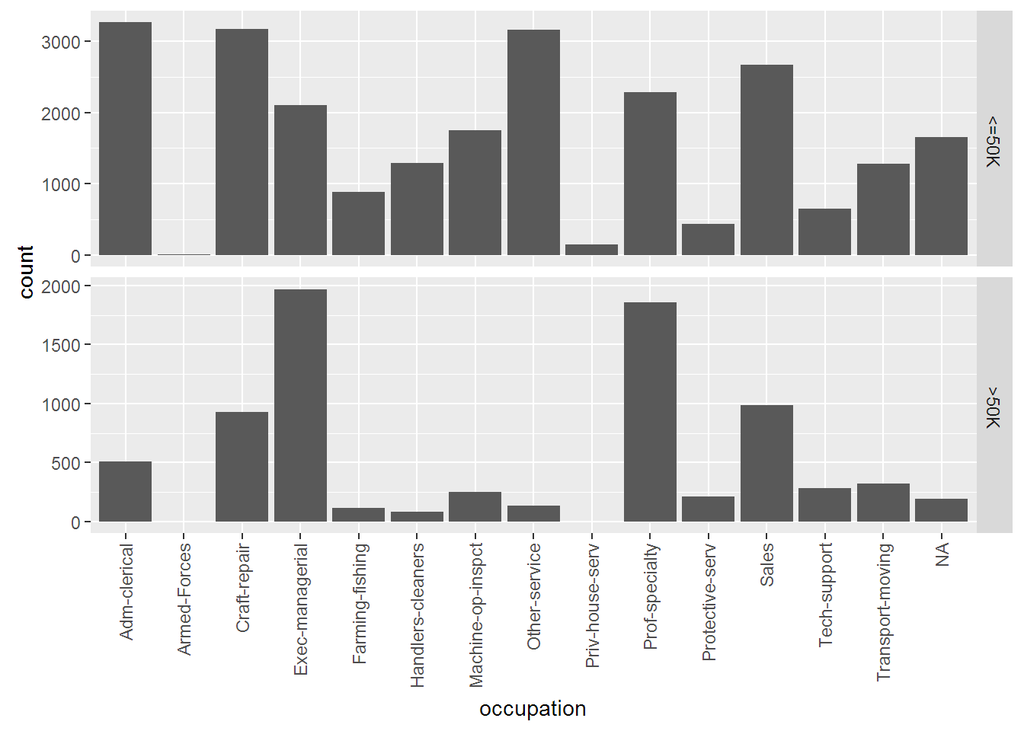

#### Feature: relationship

The number of missing values is 0.

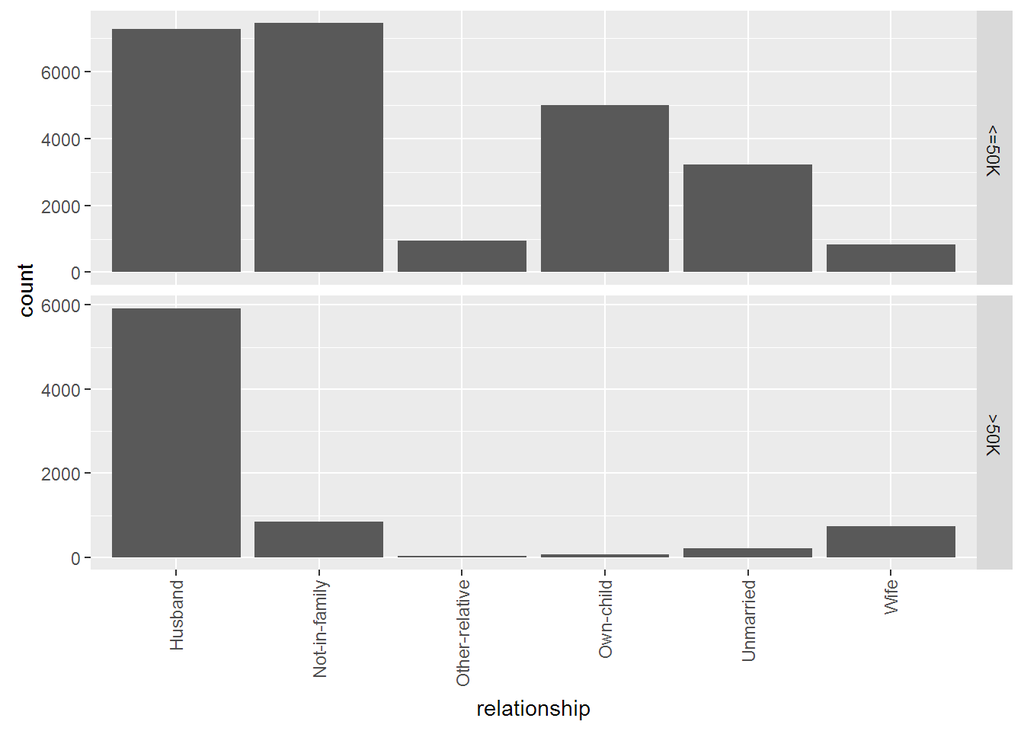

#### Feature: race

The number of missing values is 0.

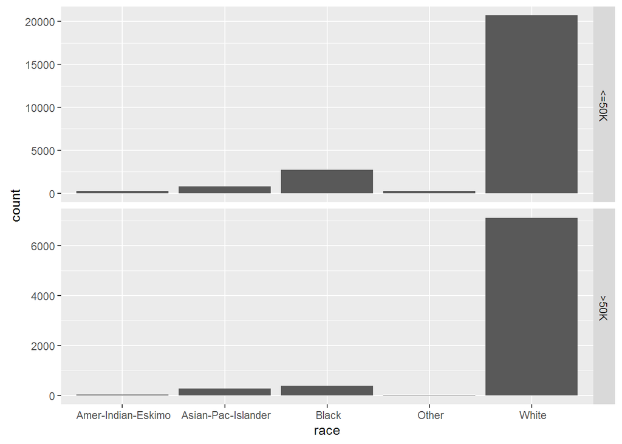

#### Feature: sex

The number of missing values is 0.

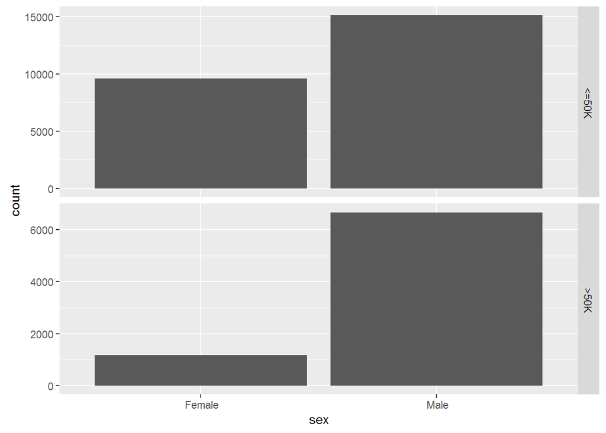

#### Feature: capital_gain

Number of missing values is 0. General statistics:

| Min. | 1st Qu. | Median | Mean | 3rd Qu. | Max. |
| --- | --- | --- | --- | --- | --- |
| 0 | 0 | 0 | 1078 | 0 | 1e+05 |

Plots:

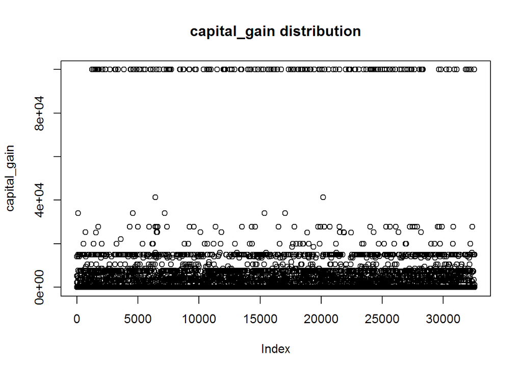

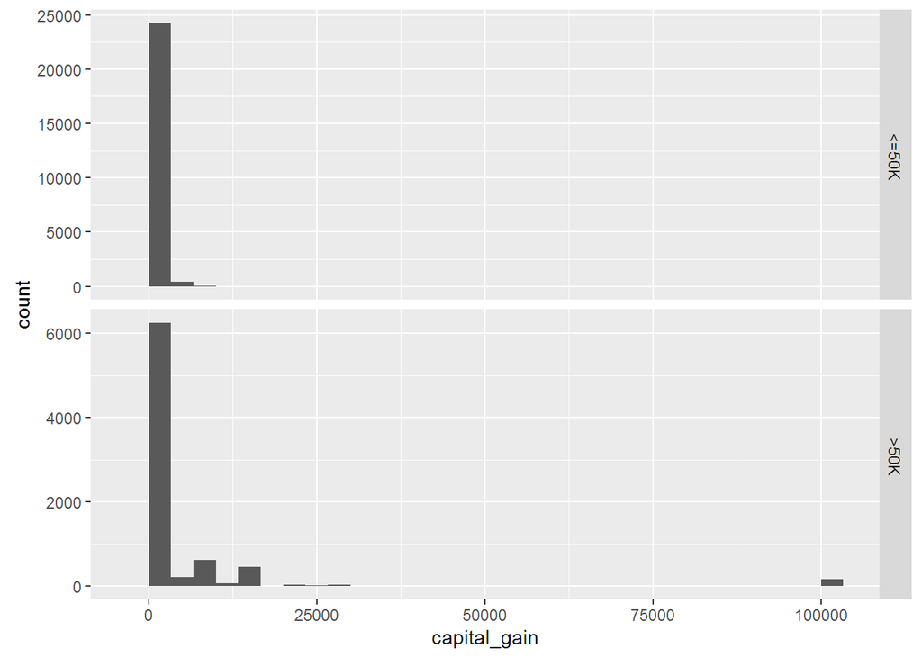

Plot for capital gain > 0

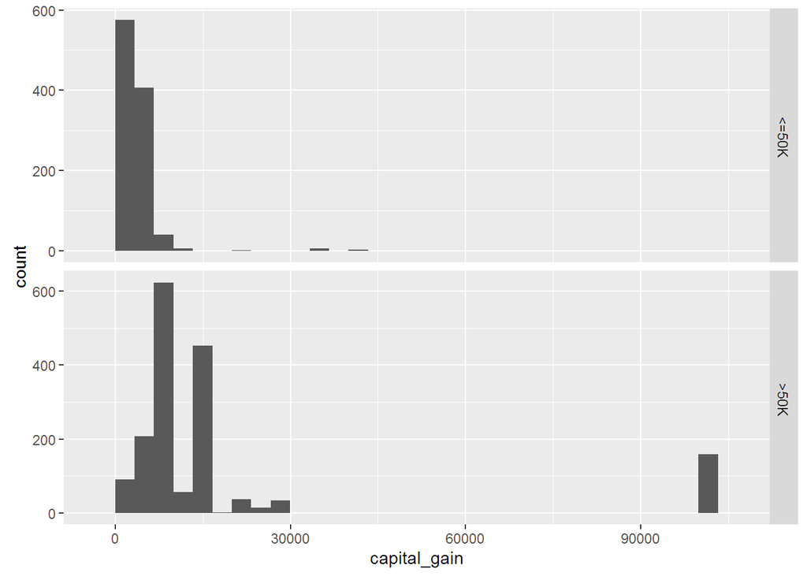

Number of obsevations where capital gain > 0

```
## [1] 2712
```

According to the plots and general statistics capital gain of 99,999 looks suspicious. Probably, the same situation as at ‘age’. I consider these errorneous data.

#### Feature: capital_loss

Number of missing values is 0. General statistics:

| Min. | 1st Qu. | Median | Mean | 3rd Qu. | Max. |
| --- | --- | --- | --- | --- | --- |
| 0 | 0 | 0 | 87.3 | 0 | 4356 |

Plots:

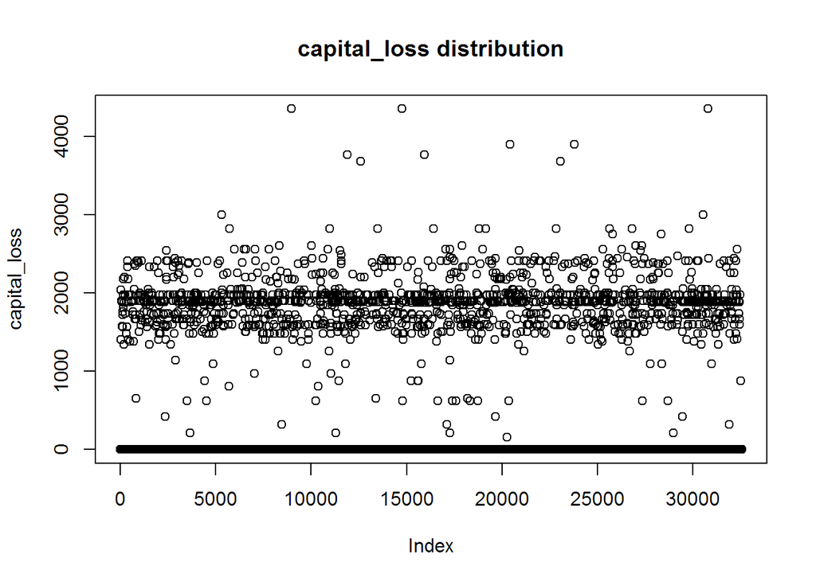

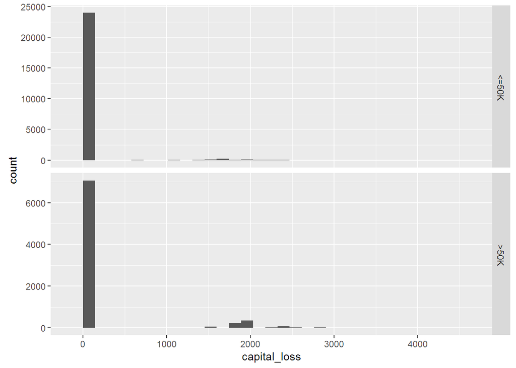

Plot for capital loss > 0

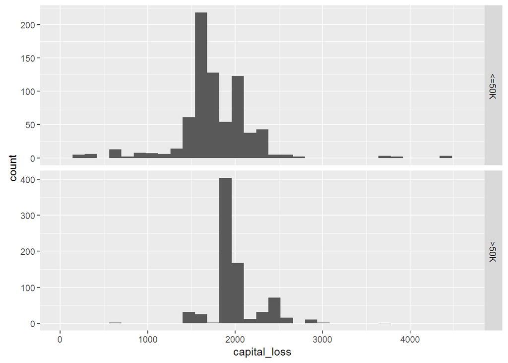

Number of obsevations where capital loss > 0

```
## [1] 1519
```

According to the plots there is no need for adjusting this feature.

#### Feature: hours_per_week

Number of missing values is 0. General statistics:

| Min. | 1st Qu. | Median | Mean | 3rd Qu. | Max. |
| --- | --- | --- | --- | --- | --- |
| 1 | 40 | 40 | 40.44 | 45 | 99 |

Distribution plots

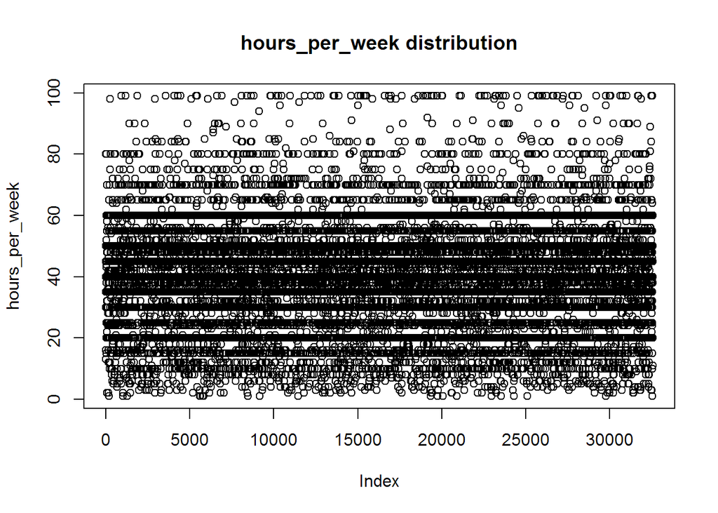

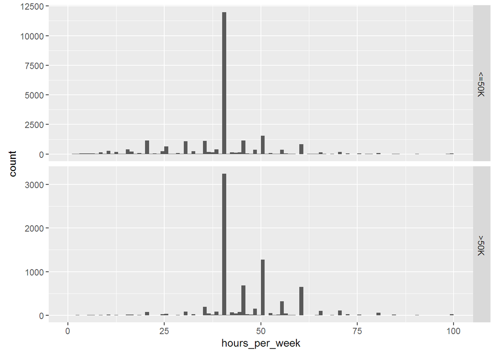

*1 : 20*, *2 : 32*, *3 : 39*, *4 : 54*, *5 : 60*, *6 : 64*, *7 : 26*, *8 : 145*, *9 : 18*, *10 : 278*, *11 : 11*, *12 : 173*, *13 : 23*, *14 : 34*, *15 : 404*, *16 : 205*, *17 : 29*, *18 : 75*, *19 : 14*, *20 : 1224*, *21 : 24*, *22 : 44*, *23 : 21*, *24 : 252*, *25 : 674*, *26 : 30*, *27 : 30*, *28 : 86*, *29 : 7*, *30 : 1149*, *31 : 5*, *32 : 266*, *33 : 39*, *34 : 28*, *35 : 1297*, *36 : 220*, *37 : 149*, *38 : 476*, *39 : 38*, *40 : 15217*, *41 : 36*, *42 : 219*, *43 : 151*, *44 : 212*, *45 : 1824*, *46 : 82*, *47 : 49*, *48 : 517*, *49 : 29*, *50 : 2819*, *51 : 13*, *52 : 138*, *53 : 25*, *54 : 41*, *55 : 694*, *56 : 97*, *57 : 17*, *58 : 28*, *59 : 5*, *60 : 1475*, *61 : 2*, *62 : 18*, *63 : 10*, *64 : 14*, *65 : 244*, *66 : 17*, *67 : 4*, *68 : 12*, *69 : 0*, *70 : 291*, *71 : 0*, *72 : 71*, *73 : 2*, *74 : 1*, *75 : 66*, *76 : 3*, *77 : 6*, *78 : 8*, *79 : 0*, *80 : 133*, *81 : 3*, *82 : 1*, *83 : 0*, *84 : 45*, *85 : 13*, *86 : 2*, *87 : 1*, *88 : 2*, *89 : 2*, *90 : 29*, *91 : 3*, *92 : 1*, *93 : 0*, *94 : 1*, *95 : 2*, *96 : 5*, *97 : 2*, *98 : 11* and *99 : 85*

Working hours above 84 per week make no sense - daily 12 hours, 7 days, and the plots and numbers shows that there are some problems with these figures. I plan to drop data above 84 hours/week.